# Risk Factor Analysis

## Outcome Variable

**Outcome Variable:** pers_wast

## Predictor Variables

**Intervention Variable:** mhtcm

**Adjustment Set:**

- arm
- W_mage
- meducyrs
- feducyrs
- single
- delta_W_mage
- delta_meducyrs
- delta_feducyrs
- delta_single

## Stratifying Variables

The analysis was stratified on these variable(s):

- agecat
- studyid
- country

## Data Summary

| agecat | studyid | country | mhtcm | pers_wast | n_cell | n |
| --- | --- | --- | --- | --- | --- | --- |
| 0-24 months | COHORTS | GUATEMALA | >=155 cm | 0 | 126 | 1026 |
| 0-24 months | COHORTS | GUATEMALA | >=155 cm | 1 | 6 | 1026 |
| 0-24 months | COHORTS | GUATEMALA | <151 cm | 0 | 653 | 1026 |
| 0-24 months | COHORTS | GUATEMALA | <151 cm | 1 | 23 | 1026 |
| 0-24 months | COHORTS | GUATEMALA | [151-155) cm | 0 | 212 | 1026 |
| 0-24 months | COHORTS | GUATEMALA | [151-155) cm | 1 | 6 | 1026 |
| 0-24 months | COHORTS | INDIA | >=155 cm | 0 | 439 | 1635 |
| 0-24 months | COHORTS | INDIA | >=155 cm | 1 | 42 | 1635 |
| 0-24 months | COHORTS | INDIA | <151 cm | 0 | 654 | 1635 |
| 0-24 months | COHORTS | INDIA | <151 cm | 1 | 67 | 1635 |
| 0-24 months | COHORTS | INDIA | [151-155) cm | 0 | 401 | 1635 |
| 0-24 months | COHORTS | INDIA | [151-155) cm | 1 | 32 | 1635 |
| 0-24 months | COHORTS | PHILIPPINES | >=155 cm | 0 | 557 | 2811 |
| 0-24 months | COHORTS | PHILIPPINES | >=155 cm | 1 | 26 | 2811 |
| 0-24 months | COHORTS | PHILIPPINES | <151 cm | 0 | 1345 | 2811 |
| 0-24 months | COHORTS | PHILIPPINES | <151 cm | 1 | 77 | 2811 |
| 0-24 months | COHORTS | PHILIPPINES | [151-155) cm | 0 | 765 | 2811 |
| 0-24 months | COHORTS | PHILIPPINES | [151-155) cm | 1 | 41 | 2811 |
| 0-24 months | Guatemala BSC | GUATEMALA | >=155 cm | 0 | 35 | 214 |
| 0-24 months | Guatemala BSC | GUATEMALA | >=155 cm | 1 | 0 | 214 |
| 0-24 months | Guatemala BSC | GUATEMALA | <151 cm | 0 | 124 | 214 |
| 0-24 months | Guatemala BSC | GUATEMALA | <151 cm | 1 | 3 | 214 |
| 0-24 months | Guatemala BSC | GUATEMALA | [151-155) cm | 0 | 51 | 214 |
| 0-24 months | Guatemala BSC | GUATEMALA | [151-155) cm | 1 | 1 | 214 |
| 0-24 months | iLiNS-Zinc | BURKINA FASO | >=155 cm | 0 | 1323 | 1645 |
| 0-24 months | iLiNS-Zinc | BURKINA FASO | >=155 cm | 1 | 164 | 1645 |
| 0-24 months | iLiNS-Zinc | BURKINA FASO | <151 cm | 0 | 34 | 1645 |
| 0-24 months | iLiNS-Zinc | BURKINA FASO | <151 cm | 1 | 10 | 1645 |
| 0-24 months | iLiNS-Zinc | BURKINA FASO | [151-155) cm | 0 | 95 | 1645 |
| 0-24 months | iLiNS-Zinc | BURKINA FASO | [151-155) cm | 1 | 19 | 1645 |

[output cut: 108 more lines]

The following strata were considered:

- agecat: 0-24 months, studyid: COHORTS, country: GUATEMALA
- agecat: 0-24 months, studyid: COHORTS, country: INDIA
- agecat: 0-24 months, studyid: COHORTS, country: PHILIPPINES
- agecat: 0-24 months, studyid: Guatemala BSC, country: GUATEMALA
- agecat: 0-24 months, studyid: iLiNS-Zinc, country: BURKINA FASO
- agecat: 0-24 months, studyid: JiVitA-3, country: BANGLADESH
- agecat: 0-24 months, studyid: Keneba, country: GAMBIA
- agecat: 0-24 months, studyid: LCNI-5, country: MALAWI
- agecat: 0-24 months, studyid: MAL-ED, country: BANGLADESH
- agecat: 0-24 months, studyid: MAL-ED, country: BRAZIL
- agecat: 0-24 months, studyid: MAL-ED, country: INDIA
- agecat: 0-24 months, studyid: MAL-ED, country: NEPAL
- agecat: 0-24 months, studyid: MAL-ED, country: PERU
- agecat: 0-24 months, studyid: MAL-ED, country: SOUTH AFRICA
- agecat: 0-24 months, studyid: MAL-ED, country: TANZANIA, UNITED REPUBLIC OF
- agecat: 0-24 months, studyid: NIH-Birth, country: BANGLADESH
- agecat: 0-24 months, studyid: NIH-Crypto, country: BANGLADESH
- agecat: 0-24 months, studyid: PROBIT, country: BELARUS
- agecat: 0-24 months, studyid: PROVIDE, country: BANGLADESH
- agecat: 0-24 months, studyid: SAS-CompFeed, country: INDIA
- agecat: 0-24 months, studyid: SAS-FoodSuppl, country: INDIA
- agecat: 0-24 months, studyid: TanzaniaChild2, country: TANZANIA, UNITED REPUBLIC OF
- agecat: 0-24 months, studyid: ZVITAMBO, country: ZIMBABWE

### Dropped Strata

Some strata were dropped due to rare outcomes:

- agecat: 0-24 months, studyid: Guatemala BSC, country: GUATEMALA
- agecat: 0-24 months, studyid: LCNI-5, country: MALAWI
- agecat: 0-24 months, studyid: MAL-ED, country: BANGLADESH
- agecat: 0-24 months, studyid: MAL-ED, country: BRAZIL
- agecat: 0-24 months, studyid: MAL-ED, country: INDIA
- agecat: 0-24 months, studyid: MAL-ED, country: NEPAL
- agecat: 0-24 months, studyid: MAL-ED, country: PERU
- agecat: 0-24 months, studyid: MAL-ED, country: SOUTH AFRICA
- agecat: 0-24 months, studyid: MAL-ED, country: TANZANIA, UNITED REPUBLIC OF
- agecat: 0-24 months, studyid: NIH-Crypto, country: BANGLADESH
- agecat: 0-24 months, studyid: PROBIT, country: BELARUS

## Methods Detail

We're interested in the causal parameters $E[Y_a]$ for all values of $a \in \mathcal{A}$. These parameters represent the mean outcome if, possibly contrary to fact, we intervened to set all units to have $A=a$. Under the randomization and positivity assumptions, these are identified by the statistical parameters $\psi_a=E_W[E_{Y|A,W}(Y|A=a,W)]$. In addition, we're interested in the mean of $Y$, $E[Y]$ under no intervention (the observed mean). We will estimate these parameters by using SuperLearner to fit the relevant likelihood factors -- $E_{Y|A,W}(Y|A=a,W)$ and $p(A=a|W)$, and then updating our likelihood fit using a joint TMLE.

For unadjusted analyses ($W=\{\}$), initial likelihoods were estimated using Lrnr_glm to estimate the simple $E(Y|A)$ and Lrnr_mean to estimate $p(A)$. For adjusted analyses, a small library containing Lrnr_glmnet, Lrnr_xgboost, and Lrnr_mean was used.

Having estimated these parameters, we will then use the delta method to estimate relative risks and attributable risks relative to a prespecified baseline level of $A$.

# Results Detail

## Results Plots

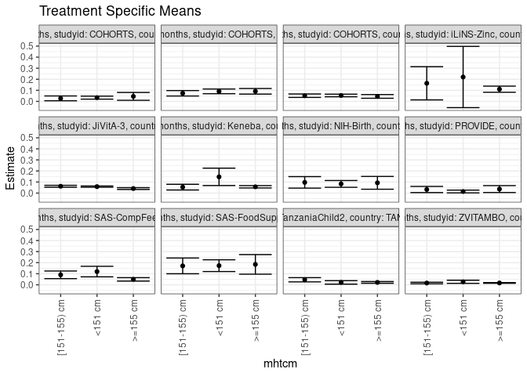

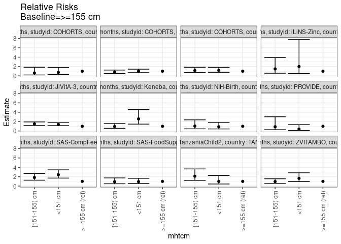

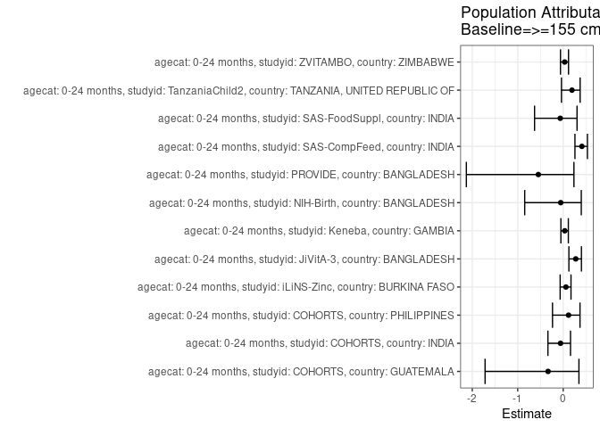

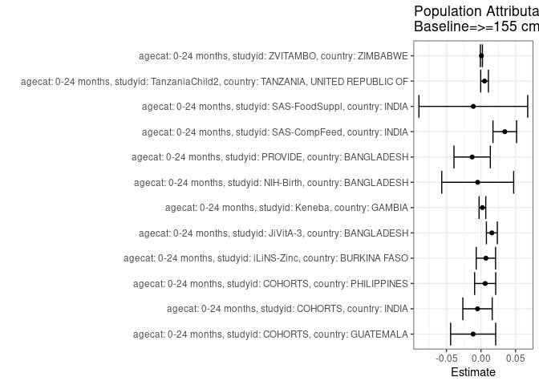

## Results Table

### Parameter: TSM

| agecat | studyid | country | intervention_level | baseline_level | estimate | ci_lower | ci_upper |
| --- | --- | --- | --- | --- | --- | --- | --- |
| 0-24 months | COHORTS | GUATEMALA | >=155 cm | NA | 0.0454545 | 0.0099029 | 0.0810062 |
| 0-24 months | COHORTS | GUATEMALA | <151 cm | NA | 0.0340237 | 0.0203508 | 0.0476966 |
| 0-24 months | COHORTS | GUATEMALA | [151-155) cm | NA | 0.0275229 | 0.0057950 | 0.0492509 |
| 0-24 months | COHORTS | INDIA | >=155 cm | NA | 0.0912589 | 0.0659227 | 0.1165951 |
| 0-24 months | COHORTS | INDIA | <151 cm | NA | 0.0907552 | 0.0695597 | 0.1119507 |
| 0-24 months | COHORTS | INDIA | [151-155) cm | NA | 0.0732541 | 0.0486559 | 0.0978523 |
| 0-24 months | COHORTS | PHILIPPINES | >=155 cm | NA | 0.0451775 | 0.0283799 | 0.0619751 |
| 0-24 months | COHORTS | PHILIPPINES | <151 cm | NA | 0.0533732 | 0.0416489 | 0.0650974 |
| 0-24 months | COHORTS | PHILIPPINES | [151-155) cm | NA | 0.0514072 | 0.0360179 | 0.0667964 |
| 0-24 months | iLiNS-Zinc | BURKINA FASO | >=155 cm | NA | 0.1102557 | 0.0825406 | 0.1379707 |
| 0-24 months | iLiNS-Zinc | BURKINA FASO | <151 cm | NA | 0.2203517 | -0.0567211 | 0.4974245 |
| 0-24 months | iLiNS-Zinc | BURKINA FASO | [151-155) cm | NA | 0.1636761 | 0.0134956 | 0.3138567 |
| 0-24 months | JiVitA-3 | BANGLADESH | >=155 cm | NA | 0.0410759 | 0.0327886 | 0.0493632 |
| 0-24 months | JiVitA-3 | BANGLADESH | <151 cm | NA | 0.0584137 | 0.0529298 | 0.0638975 |
| 0-24 months | JiVitA-3 | BANGLADESH | [151-155) cm | NA | 0.0617000 | 0.0531108 | 0.0702892 |
| 0-24 months | Keneba | GAMBIA | >=155 cm | NA | 0.0568769 | 0.0461810 | 0.0675728 |
| 0-24 months | Keneba | GAMBIA | <151 cm | NA | 0.1467860 | 0.0681322 | 0.2254398 |
| 0-24 months | Keneba | GAMBIA | [151-155) cm | NA | 0.0537526 | 0.0280255 | 0.0794796 |
| 0-24 months | NIH-Birth | BANGLADESH | >=155 cm | NA | 0.0927835 | 0.0349925 | 0.1505745 |
| 0-24 months | NIH-Birth | BANGLADESH | <151 cm | NA | 0.0830671 | 0.0524639 | 0.1136702 |
| 0-24 months | NIH-Birth | BANGLADESH | [151-155) cm | NA | 0.0967742 | 0.0446880 | 0.1488603 |
| 0-24 months | PROVIDE | BANGLADESH | >=155 cm | NA | 0.0362319 | 0.0050301 | 0.0674337 |
| 0-24 months | PROVIDE | BANGLADESH | <151 cm | NA | 0.0143678 | 0.0018551 | 0.0268805 |
| 0-24 months | PROVIDE | BANGLADESH | [151-155) cm | NA | 0.0324675 | 0.0044529 | 0.0604822 |
| 0-24 months | SAS-CompFeed | INDIA | >=155 cm | NA | 0.0491300 | 0.0336953 | 0.0645648 |
| 0-24 months | SAS-CompFeed | INDIA | <151 cm | NA | 0.1194392 | 0.0718928 | 0.1669856 |
| 0-24 months | SAS-CompFeed | INDIA | [151-155) cm | NA | 0.0899800 | 0.0554871 | 0.1244730 |
| 0-24 months | SAS-FoodSuppl | INDIA | >=155 cm | NA | 0.1844400 | 0.0958643 | 0.2730156 |
| 0-24 months | SAS-FoodSuppl | INDIA | <151 cm | NA | 0.1729160 | 0.1196855 | 0.2261465 |
| 0-24 months | SAS-FoodSuppl | INDIA | [151-155) cm | NA | 0.1709771 | 0.0997455 | 0.2422087 |
| 0-24 months | TanzaniaChild2 | TANZANIA, UNITED REPUBLIC OF | >=155 cm | NA | 0.0215613 | 0.0137972 | 0.0293255 |
| 0-24 months | TanzaniaChild2 | TANZANIA, UNITED REPUBLIC OF | <151 cm | NA | 0.0214724 | 0.0057337 | 0.0372111 |
| 0-24 months | TanzaniaChild2 | TANZANIA, UNITED REPUBLIC OF | [151-155) cm | NA | 0.0454545 | 0.0264562 | 0.0644529 |
| 0-24 months | ZVITAMBO | ZIMBABWE | >=155 cm | NA | 0.0165488 | 0.0134397 | 0.0196579 |
| 0-24 months | ZVITAMBO | ZIMBABWE | <151 cm | NA | 0.0271566 | 0.0132023 | 0.0411108 |
| 0-24 months | ZVITAMBO | ZIMBABWE | [151-155) cm | NA | 0.0158126 | 0.0087157 | 0.0229096 |

### Parameter: E(Y)

| agecat | studyid | country | intervention_level | baseline_level | estimate | ci_lower | ci_upper |
| --- | --- | --- | --- | --- | --- | --- | --- |
| 0-24 months | COHORTS | GUATEMALA | NA | NA | 0.0341131 | 0.0230006 | 0.0452255 |
| 0-24 months | COHORTS | INDIA | NA | NA | 0.0862385 | 0.0726276 | 0.0998495 |
| 0-24 months | COHORTS | PHILIPPINES | NA | NA | 0.0512273 | 0.0430760 | 0.0593786 |
| 0-24 months | iLiNS-Zinc | BURKINA FASO | NA | NA | 0.1173252 | 0.0921861 | 0.1424644 |
| 0-24 months | JiVitA-3 | BANGLADESH | NA | NA | 0.0567893 | 0.0526505 | 0.0609282 |
| 0-24 months | Keneba | GAMBIA | NA | NA | 0.0589601 | 0.0490104 | 0.0689098 |
| 0-24 months | NIH-Birth | BANGLADESH | NA | NA | 0.0880150 | 0.0639627 | 0.1120673 |
| 0-24 months | PROVIDE | BANGLADESH | NA | NA | 0.0234375 | 0.0117074 | 0.0351676 |
| 0-24 months | SAS-CompFeed | INDIA | NA | NA | 0.0835322 | 0.0594080 | 0.1076564 |
| 0-24 months | SAS-FoodSuppl | INDIA | NA | NA | 0.1733333 | 0.1349698 | 0.2116969 |
| 0-24 months | TanzaniaChild2 | TANZANIA, UNITED REPUBLIC OF | NA | NA | 0.0267229 | 0.0198773 | 0.0335686 |
| 0-24 months | ZVITAMBO | ZIMBABWE | NA | NA | 0.0171191 | 0.0143076 | 0.0199306 |

### Parameter: RR

| agecat | studyid | country | intervention_level | baseline_level | estimate | ci_lower | ci_upper |
| --- | --- | --- | --- | --- | --- | --- | --- |
| 0-24 months | COHORTS | GUATEMALA | >=155 cm | >=155 cm | 1.0000000 | 1.0000000 | 1.000000 |
| 0-24 months | COHORTS | GUATEMALA | <151 cm | >=155 cm | 0.7485207 | 0.3106798 | 1.803411 |
| 0-24 months | COHORTS | GUATEMALA | [151-155) cm | >=155 cm | 0.6055046 | 0.1992921 | 1.839690 |
| 0-24 months | COHORTS | INDIA | >=155 cm | >=155 cm | 1.0000000 | 1.0000000 | 1.000000 |
| 0-24 months | COHORTS | INDIA | <151 cm | >=155 cm | 0.9944810 | 0.6920261 | 1.429126 |
| 0-24 months | COHORTS | INDIA | [151-155) cm | >=155 cm | 0.8027066 | 0.5194266 | 1.240479 |
| 0-24 months | COHORTS | PHILIPPINES | >=155 cm | >=155 cm | 1.0000000 | 1.0000000 | 1.000000 |
| 0-24 months | COHORTS | PHILIPPINES | <151 cm | >=155 cm | 1.1814097 | 0.7670860 | 1.819521 |
| 0-24 months | COHORTS | PHILIPPINES | [151-155) cm | >=155 cm | 1.1378925 | 0.7060883 | 1.833764 |
| 0-24 months | iLiNS-Zinc | BURKINA FASO | >=155 cm | >=155 cm | 1.0000000 | 1.0000000 | 1.000000 |
| 0-24 months | iLiNS-Zinc | BURKINA FASO | <151 cm | >=155 cm | 1.9985521 | 0.5148313 | 7.758291 |
| 0-24 months | iLiNS-Zinc | BURKINA FASO | [151-155) cm | >=155 cm | 1.4845143 | 0.5634265 | 3.911393 |
| 0-24 months | JiVitA-3 | BANGLADESH | >=155 cm | >=155 cm | 1.0000000 | 1.0000000 | 1.000000 |
| 0-24 months | JiVitA-3 | BANGLADESH | <151 cm | >=155 cm | 1.4220913 | 1.1457499 | 1.765083 |
| 0-24 months | JiVitA-3 | BANGLADESH | [151-155) cm | >=155 cm | 1.5020963 | 1.1684639 | 1.930991 |
| 0-24 months | Keneba | GAMBIA | >=155 cm | >=155 cm | 1.0000000 | 1.0000000 | 1.000000 |
| 0-24 months | Keneba | GAMBIA | <151 cm | >=155 cm | 2.5807678 | 1.4620969 | 4.555349 |
| 0-24 months | Keneba | GAMBIA | [151-155) cm | >=155 cm | 0.9450685 | 0.5651168 | 1.580477 |
| 0-24 months | NIH-Birth | BANGLADESH | >=155 cm | >=155 cm | 1.0000000 | 1.0000000 | 1.000000 |
| 0-24 months | NIH-Birth | BANGLADESH | <151 cm | >=155 cm | 0.8952787 | 0.4341874 | 1.846032 |
| 0-24 months | NIH-Birth | BANGLADESH | [151-155) cm | >=155 cm | 1.0430108 | 0.4579132 | 2.375716 |
| 0-24 months | PROVIDE | BANGLADESH | >=155 cm | >=155 cm | 1.0000000 | 1.0000000 | 1.000000 |
| 0-24 months | PROVIDE | BANGLADESH | <151 cm | >=155 cm | 0.3965517 | 0.1165174 | 1.349612 |
| 0-24 months | PROVIDE | BANGLADESH | [151-155) cm | >=155 cm | 0.8961039 | 0.2648038 | 3.032442 |
| 0-24 months | SAS-CompFeed | INDIA | >=155 cm | >=155 cm | 1.0000000 | 1.0000000 | 1.000000 |
| 0-24 months | SAS-CompFeed | INDIA | <151 cm | >=155 cm | 2.4310831 | 1.7037375 | 3.468941 |
| 0-24 months | SAS-CompFeed | INDIA | [151-155) cm | >=155 cm | 1.8314674 | 1.2554105 | 2.671854 |
| 0-24 months | SAS-FoodSuppl | INDIA | >=155 cm | >=155 cm | 1.0000000 | 1.0000000 | 1.000000 |
| 0-24 months | SAS-FoodSuppl | INDIA | <151 cm | >=155 cm | 0.9375191 | 0.5311360 | 1.654834 |
| 0-24 months | SAS-FoodSuppl | INDIA | [151-155) cm | >=155 cm | 0.9270067 | 0.4923766 | 1.745293 |
| 0-24 months | TanzaniaChild2 | TANZANIA, UNITED REPUBLIC OF | >=155 cm | >=155 cm | 1.0000000 | 1.0000000 | 1.000000 |
| 0-24 months | TanzaniaChild2 | TANZANIA, UNITED REPUBLIC OF | <151 cm | >=155 cm | 0.9958748 | 0.4400867 | 2.253571 |
| 0-24 months | TanzaniaChild2 | TANZANIA, UNITED REPUBLIC OF | [151-155) cm | >=155 cm | 2.1081505 | 1.2142426 | 3.660140 |
| 0-24 months | ZVITAMBO | ZIMBABWE | >=155 cm | >=155 cm | 1.0000000 | 1.0000000 | 1.000000 |
| 0-24 months | ZVITAMBO | ZIMBABWE | <151 cm | >=155 cm | 1.6410023 | 0.9495887 | 2.835847 |
| 0-24 months | ZVITAMBO | ZIMBABWE | [151-155) cm | >=155 cm | 0.9555173 | 0.5874052 | 1.554316 |

### Parameter: PAR

| agecat | studyid | country | intervention_level | baseline_level | estimate | ci_lower | ci_upper |
| --- | --- | --- | --- | --- | --- | --- | --- |
| 0-24 months | COHORTS | GUATEMALA | >=155 cm | NA | -0.0113415 | -0.0439327 | 0.0212497 |
| 0-24 months | COHORTS | INDIA | >=155 cm | NA | -0.0050203 | -0.0262530 | 0.0162124 |
| 0-24 months | COHORTS | PHILIPPINES | >=155 cm | NA | 0.0060498 | -0.0091880 | 0.0212876 |
| 0-24 months | iLiNS-Zinc | BURKINA FASO | >=155 cm | NA | 0.0070695 | -0.0069324 | 0.0210714 |
| 0-24 months | JiVitA-3 | BANGLADESH | >=155 cm | NA | 0.0157134 | 0.0078180 | 0.0236089 |
| 0-24 months | Keneba | GAMBIA | >=155 cm | NA | 0.0020832 | -0.0027516 | 0.0069179 |
| 0-24 months | NIH-Birth | BANGLADESH | >=155 cm | NA | -0.0047685 | -0.0567779 | 0.0472409 |
| 0-24 months | PROVIDE | BANGLADESH | >=155 cm | NA | -0.0127944 | -0.0390871 | 0.0134983 |
| 0-24 months | SAS-CompFeed | INDIA | >=155 cm | NA | 0.0344022 | 0.0172931 | 0.0515112 |
| 0-24 months | SAS-FoodSuppl | INDIA | >=155 cm | NA | -0.0111066 | -0.0897419 | 0.0675287 |
| 0-24 months | TanzaniaChild2 | TANZANIA, UNITED REPUBLIC OF | >=155 cm | NA | 0.0051616 | -0.0004171 | 0.0107402 |
| 0-24 months | ZVITAMBO | ZIMBABWE | >=155 cm | NA | 0.0005703 | -0.0009400 | 0.0020807 |

### Parameter: PAF

| agecat | studyid | country | intervention_level | baseline_level | estimate | ci_lower | ci_upper |
| --- | --- | --- | --- | --- | --- | --- | --- |
| 0-24 months | COHORTS | GUATEMALA | >=155 cm | NA | -0.3324675 | -1.7178844 | 0.3467457 |
| 0-24 months | COHORTS | INDIA | >=155 cm | NA | -0.0582146 | -0.3355216 | 0.1615126 |
| 0-24 months | COHORTS | PHILIPPINES | >=155 cm | NA | 0.1180973 | -0.2347552 | 0.3701161 |
| 0-24 months | iLiNS-Zinc | BURKINA FASO | >=155 cm | NA | 0.0602560 | -0.0665407 | 0.1719783 |
| 0-24 months | JiVitA-3 | BANGLADESH | >=155 cm | NA | 0.2766970 | 0.1256795 | 0.4016299 |
| 0-24 months | Keneba | GAMBIA | >=155 cm | NA | 0.0353321 | -0.0499524 | 0.1136892 |
| 0-24 months | NIH-Birth | BANGLADESH | >=155 cm | NA | -0.0541785 | -0.8462698 | 0.3980878 |
| 0-24 months | PROVIDE | BANGLADESH | >=155 cm | NA | -0.5458937 | -2.1301295 | 0.2365212 |
| 0-24 months | SAS-CompFeed | INDIA | >=155 cm | NA | 0.4118434 | 0.2586684 | 0.5333691 |
| 0-24 months | SAS-FoodSuppl | INDIA | >=155 cm | NA | -0.0640767 | -0.6294485 | 0.3051273 |
| 0-24 months | TanzaniaChild2 | TANZANIA, UNITED REPUBLIC OF | >=155 cm | NA | 0.1931520 | -0.0377679 | 0.3726886 |
| 0-24 months | ZVITAMBO | ZIMBABWE | >=155 cm | NA | 0.0333157 | -0.0588821 | 0.1174857 |